# Turtle

## Turtle Exercise 1

### 1.1 Getting a turtle.

Let’s install the `TurtleGraphics` package. The package *is* available on CRAN so you could install it the normal way through the RStudio menus, but – because I wanted to make a couple of minor tweaks to how the package behaved – let’s install a slightly modified version that I’ve posted to my github page. Here’s how we do that:

```r
install.packages("devtools")                # first we need the developer tools...
library(devtools)                           # next we need to load that package...
install_github("djnavarro/TurtleGraphics")  # ... now we can install the package from github
```

(Remember, you only need to do this first part once!) Wait a moment while it downloads, and then load the `TurtleGraphics` package. Create a new R script, and add the following commands. You don’t need to add the comments for the sake of this exercise, but in real life I *strongly* recommend adding comments to your code!

```r
library(TurtleGraphics) # load the TurtleGraphics package
turtle_init()           # initialise the terrarium
```

When you run it, you should see this:

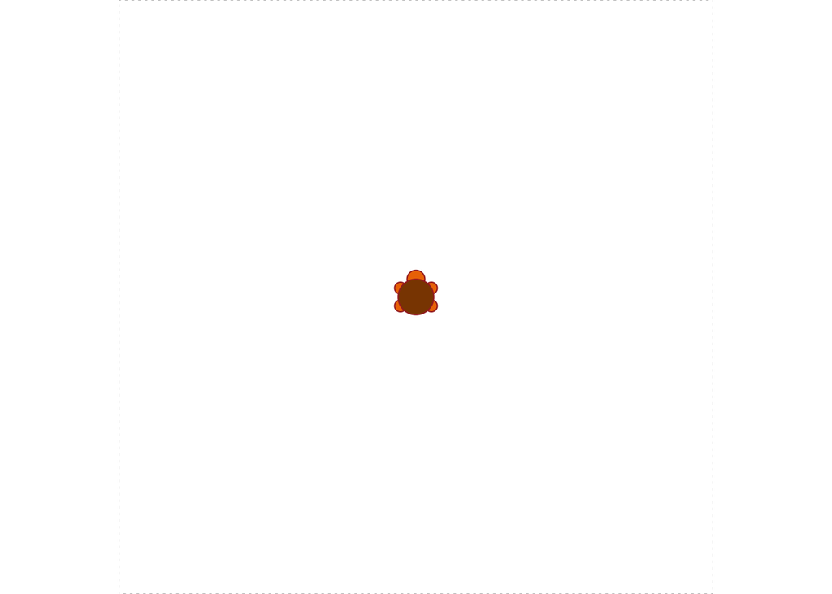

Yay! A turtle

### 1.2 Moving the turtle

Our turtle can do a few things. She - I’ve decided this is a girl turtle, apparently - can move forwards and backwards, and she can turn to the left or the right. I’d like her to draw a triangle for me, so I’ll add some additional commands to the script:

```r
library(TurtleGraphics) # load the TurtleGraphics package
turtle_init()           # initialise the terrarium
turtle_forward(distance = 10)  # move 10 steps forward
```

I’ll let you run the script to see what happens. Once you’ve done that, you’ll need to get her to turn and move again, which you can do like this:

```r
library(TurtleGraphics) # load the TurtleGraphics package
turtle_init()           # initialise the terrarium
turtle_forward(distance = 10)  # move 10 steps forward
turtle_left(angle = 120) # turn 120 degrees
turtle_forward(distance = 10)  # move 10 steps forward
```

Finish the triangle!

### 1.3 Drawing a hexagon

For the next exercise, modify the script so the turtle produces a hexagon like the one shown below

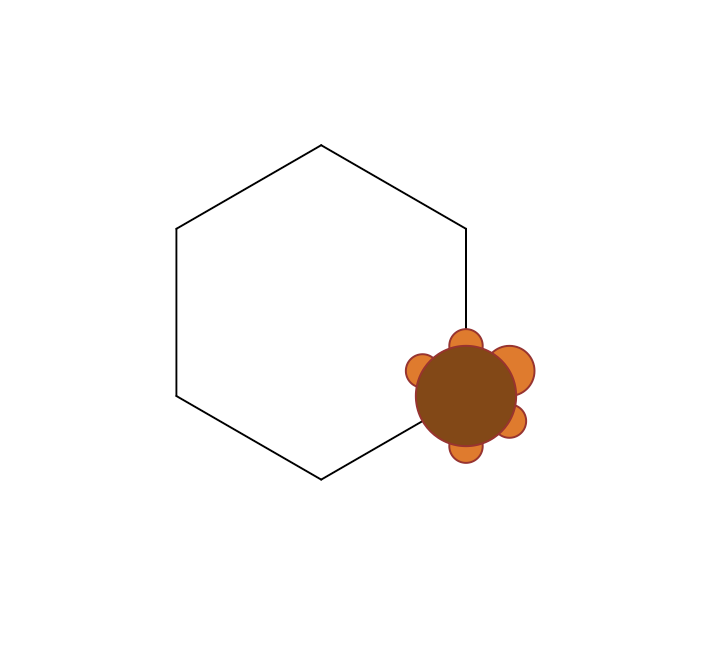